今回の資料置き場 → [http://ps-tb-jp.github.io/spm_chubu_symp2021/](https://ps-tb-jp.github.io/spm_chubu_symp2021/)

# 何故コミュニティー型チーム活動には PMが不要なのか？

～COVID-19対策サイト開発から学ぶ～

松尾谷 徹

2021/11/17

# 青山幹雄先生を偲ぶ

## .

- ご冥福をお祈りいたします．
  - 今日はDXを熱く語る
  - 新時代のPM，DXの話題
  - 先生とは30年来のソフト工学・仲間

# 自己紹介

## 松尾谷 徹

- 前期高齢者： 香川県 -> 大阪育ち -> 東京出稼ぎ
- 職歴：1972:電気メーカ～ 2002:独立 デバッグ工学研究所
- 経験：HW開発,OS開発,PM育成,国際規格,コンサル
- 兼任講師歴：明治大，東京理科大，法政大
- SPMとの関わり：[google scholar “PM学会 松尾谷 PS”で検索](https://scholar.google.co.jp/scholar?hl=ja&as_sdt=0%2C5&q=PM%E5%AD%A6%E4%BC%9A+%E6%9D%BE%E5%B0%BE%E8%B0%B7%E3%80%80PS&btnG=)
- 最近の興味分野：  
  concolic-testing, チームとモチベーション，tidyverseパッケージ

# 今日の内容

## Dataから読み取る PM, DX

- 事例の紹介：
  - 東京都が主催したOSSによる
  - COVID-19対策サイト開発
- 紹介内容は：
  - 公開されているData
  - Git log と GitHub API
  - RStudio/ Rでの分析
  - Rmd(マークダウン) 記述でslide作成

## Zoom と併用するTool

- CodiMD：質問やコメント用サイト
  - https://note.ps-tb.jp
  - login - UID spm1117(@ps-tb.jp)
  - pass chubu1117
- 同時書き込み可，編集可
- 質問やコメントをお願いします．
- 関連する情報があれば書込み願います．
  - 質問の回答は終了後になります．
- このslideはgithub.ioにUp

# 事例の紹介 「COVID-19対策サイト開発」

## 新型コロナ：経緯

- 2020年2月 国内での発症始まる
  - 2/3 ダイヤモンド・プリンセス横浜入船
- COVID-19関連情報が輻輳
  - 各機関のサイトに問合せ集中
- 東京都が対策サイトを発注
  - OSSでの開発依頼
  - 2/28 GitHub にリポジトリ作成
  - 3/5 最初のリリース，運用開始
  - 国内外から応援者が続出！！

## 驚異の高速開発，高生産性

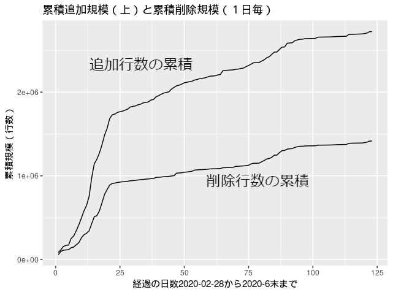

#### 図1. 累積追加規模（6末まで）

###### 新規立上り 最初の1週は 普通の開発状態 2週目から爆速 2週で2M行!! リリース継続で その後の機能成長 3ヶ月で1M行 改善対応力 不要コードの消去 これらは理想の DevOps実現

## 驚異の開発活力

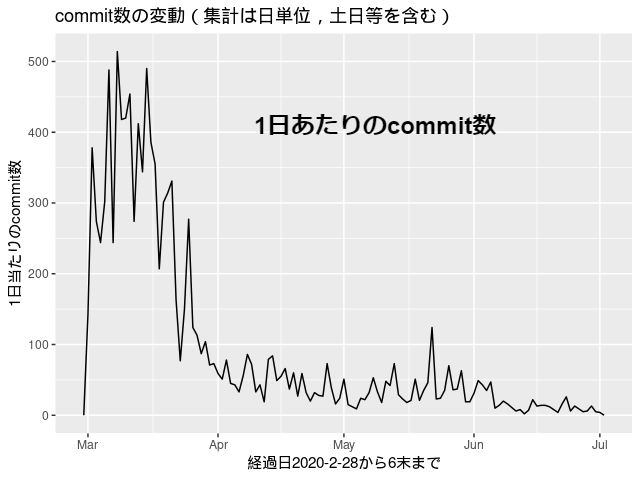

#### 図2. 1日のコミット数（6末まで）

###### 開発活力の視覚化 CI/CDの性能 (継続的インテグレーション/継続的デリバリー) 1日のcommit数 100 commits/day超 通常10件/day位 限界は100件/day ところが爆速超え 4週目から安定化

## 開発の謎 ？！

- プロジェクト開始後1Week で
  - サイト開設，公開開始
  - その後２週間ほどは爆速
- 主な謎を３つ選ぶと
1. エンジニアはどこから？
2. 神業プロマネはどこから？
3. DX指向の仕様はどこから？

# 謎 ？ 謎 ？ 謎 ？

# 1. エンジニアはどこから？

## 人的資源管理

- 経営学だと人的資源管理
- PMなら工数積算？
  - そんな理屈の謎ではなく
  - 予算すら付いていない状況下で
  - 大量の工数が投入され，結果も出ている．
- PM経験から
  - 工数を短期間で集められない
  - 集めても，直ぐには成果につながらない
  - この事例を真似できない．

## 怪しい？何か裏があるのでは？

## 1.1 驚異の動員力

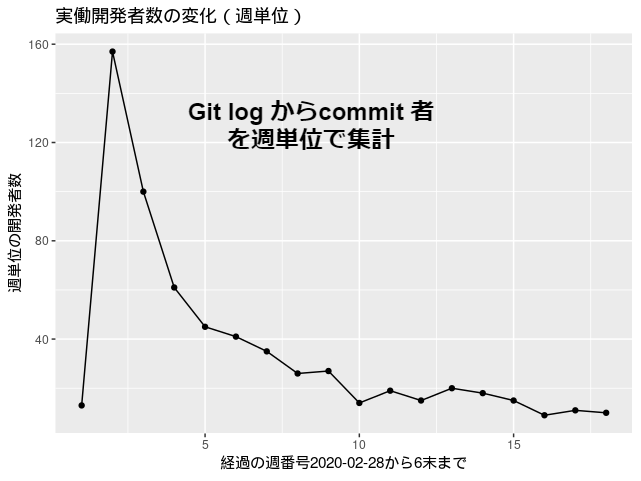

#### 図3. 実働開発者数(6末まで)

###### 実態を視覚化する 表示は週単位の 実働開発者数 実働とは： Commit実績あり 2週目で150名 驚異の動員力 動員= 即成果 混乱が見えない 知らない人達が 整然と活動

## 1.2 要員の流動性

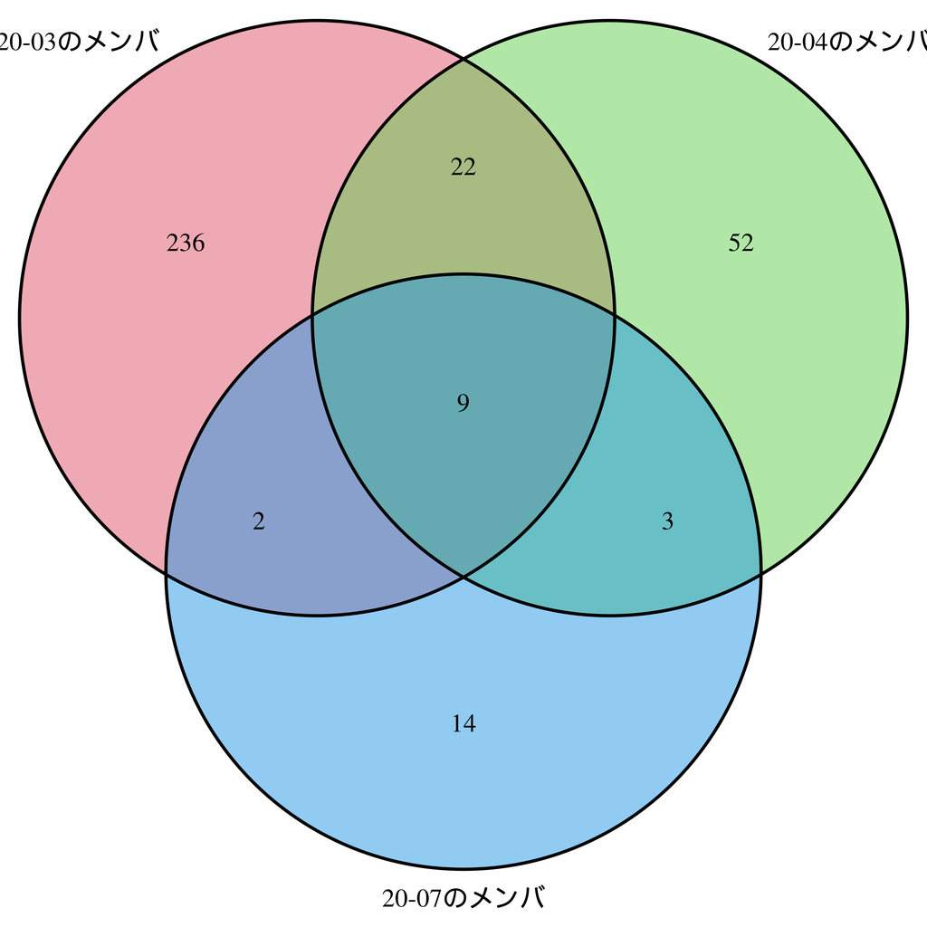

###### 図4. 20年3月/4月/7月の要員構成（venn図)

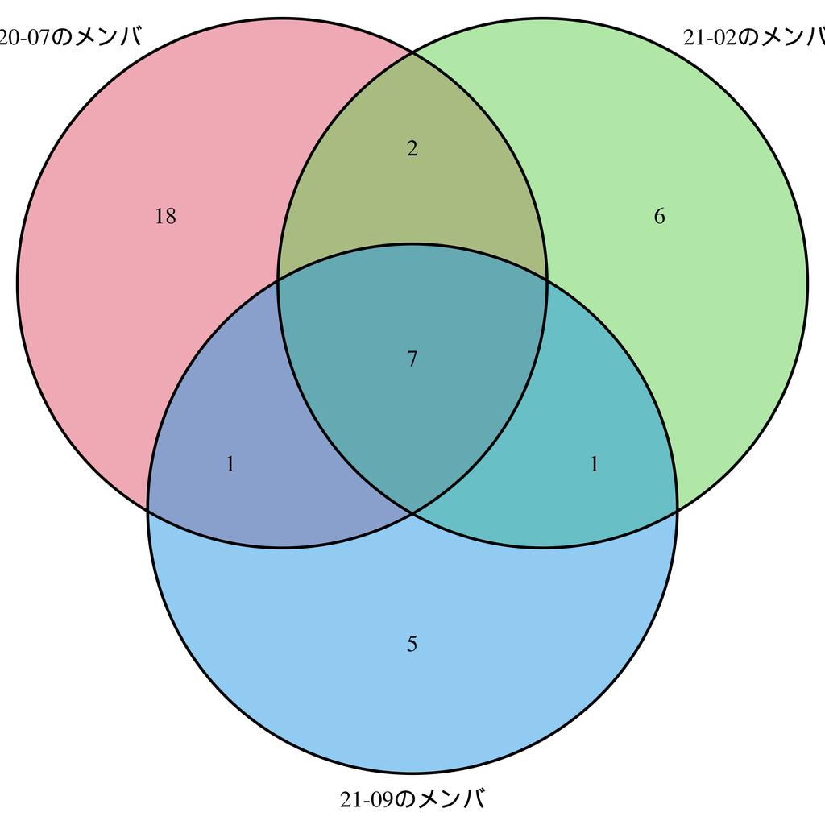

###### 図5. 20年7月/21年2月/9月の要員構成（venn図)

## 1.3 成果物の構成

#### 表1. 全期間における更新数

| No | 拡張子 | 修正回数 | 比率％ | 機能 |
| --- | --- | --- | --- | --- |
| 1 | vue | 30,972 | 30 | コード |
| 2 | json | 22,806 | 22 | データ |
| 3 | png | 19,621 | 19 | データ図 |
| 4 | md | 8,898 | 8 | データ |
| 5 | csv | 5,504 | 5 | データ |
| 6 | ts | 3,103 | 3 | コード |
| 7 | svg | 2,023 | 2 | データ図 |
| 8 | yml | 1,693 | 1 | データ |
| 9 | lock | 1,456 | 1 | その他 |

###### 表の9種類で90% コードとデータ 図は行数対象外 運用が含まれる DevOps 膨大なアクセス 非組織化要員 衝突問題は？

## 1.4 情報衝突回避

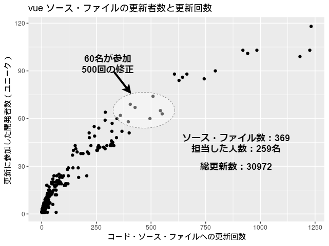

#### 図7. 複数担当でも衝突生じず

###### 使用言語：vue 開発者:259 ソース:369Files 担当は？ 競争的改善？ X軸:fileの更新数 Y軸:更新者数 重複除去の値 混乱が見えない 知らない人達が 整然と活動 スーパーPM？

## 派生開発は難しいか？

- 業界常識としては
  - 他社や他人が作ったコード
  - そこに派生開発のは難儀
  - 担当を固定し，工数がかかる
  - 理想として，属人性排除
- 事例の世界では
  - vueの例 30名～100名が
  - 多くにソースファイルに対して
  - 参加後，即，改修できている
  - 同時更新でも衝突していない

# 2. 神業プロマネはどこから？

## 2.1 PM痕跡・見当たらない

- PM痕跡とは
  - 計画，体制，リスケ，
  - 進捗会議，ほげほげ管理
- 存在するのはissue 記録
  - これはGitHubの機能
  - 問題処理票みたいなもの
  - バグから機能要件まで何でもあり
- issueの手順＝GitHubフロー
  - この規範下で自律的行動

## 2.2 驚異の課題処理能力

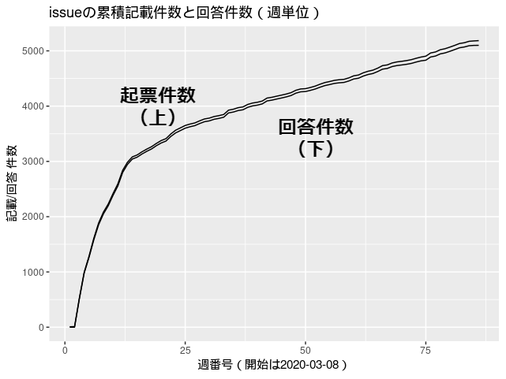

#### 図8. issue（課題処理）の記載/回答

###### issue: 仕様提案から 不具合まで 累積5,000件 未回答率は1.6% 回答管理者は不在 自律的 沢山の目（公開）

## 2.3 驚異の解決速度

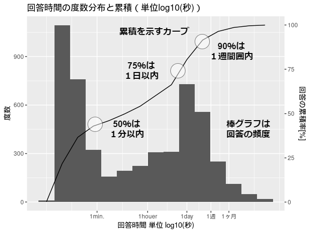

#### 図9. 課題処理時間の頻度と累積

###### 1分以下？ 50%ほど 1日以下 70%ほど 1週以下 90%ほど なんでこんなに速いの？ 誰が担当するの？

# 3. DX指向の仕様はどこから？

## 3.1 要求分析は？

- この事例では，感染症に対する迅速な情報提供
  - ２月の開始時：既存データは限定的
  - その後，ワクチンなどで要件は変化
  - 継続的な要求追加や変更が生じた
- 静的分析からトラッキング型の要件対応
  - 事例では，国内外の有識者が参加し  
    issueとして様々な提案
  - 速く実装して，評価を受けフィードバック
- この方式で混乱なく実現できたのは，  
  仕様をマイクロサービスとして設計

## 3.2 他都市への展開

- 自治体間の連携 Vs. 競争
  - SIビジネスだと独自性を競う
    - 結果として個別発注
  - 社会インフラだと連携が好ましい
    - 誰が連携を推進できるのか？
    - 広義のDX・プロマネ
- この事例では２０以上の自治体が流用
  - 札幌，名古屋，大阪，福岡，長野
  - 沖縄，浜松，千葉，新潟，滋賀
- 注目すべき成果

# Open Science

## Open Scienceとは

- [wikipediaに説明がある](https://ja.wikipedia.org/wiki/%E3%82%AA%E3%83%BC%E3%83%97%E3%83%B3%E3%82%B5%E3%82%A4%E3%82%A8%E3%83%B3%E3%82%B9)
- 歴史的経緯
  - 科学者のパトロン -> 秘密主義，独占
  - 科学雑誌（ジャーナル）によりオープン化
  - 有償図書の障壁 –> オープン化
- covid19 対応ワクチン開発もOpen Scienceの成果
  - 本事例も
  - 背景にDataのオープン化

## OSSは進化した

- OSSもOpen Scienceの一環
  - 初期：営利的独占との戦い
  - プログラムコードのオープン化
- さらに進化
  - オープンデータ
  - オープンメソドロジー
  - 教育・訓練の場
- これらは，Open Scienceのトレンド
  - 原点は「伽藍とバザール 」

## Open Scienceとビジネス

- 日本のSIビジネスの現状
  - 秘密・独占型で進んできた
  - ギャップは感じているが，
  - Open化の話題–> 自身の雇用問題
  - 不安なのでこの話題を避ける
- SIビジネスの変化
  - 変化は生ずるが
  - データ分析の枠外なのでここでは扱わない
- PMやエンジニアのスキル獲得
  - この事例＝高効率＝背後に高スキル
  - この種のスキルを学んで損はない
- どうやって学ぶの
  - 日常業務経験で得られない

## これからPMが学ぶこと

- 現在のPM資格教科書だけではスキル不足
  - 現行ビジネスでも不足ぎみ？
- 新たなスキル獲得が必要
  - どこで学ぶのか？
- 学ぶリソースもOSSが有望？
  - 現在，OSS上での成長Data収集と
  - モデル化を進めています．

# まとめ

## まとめ

- Open ScienceによるDX開発事例
  - Data（事実）を視覚化し紹介した
- 明らかに高効率：それを支えたのは
  - 人的資源，OSSコミュニティ文化
  - 日本でも人材が育っている
- 負けるな！！ プロのPMやエンジニア！！
  - 学ぶ人を応援します．

## おまけ

- 学び方 先ずは
  - Gitなどのlogからプロジェクト状況を取り出し
  - 視覚化や比較分析を行うスキル
- ここで紹介した程度のものなら難しくありません．
  - テキスト作る体力はないが，
  - 一緒にオンライン勉強会程度ならできます．
- note.ps-tb.jp でお知らせします．

# ★CodiMD

- 直接見るなら
- https://note.ps-tb.jp/9QqTgMqpSCKG2TRonNZuOw?view ー